# As-a-Statistician-Advanced Linear Regression

### Plotting Interactions

[Exploring interactions with continuous predictors in regression models](https://cran.r-project.org/web/packages/interactions/vignettes/interactions.html#plotting_interactions)

**Interactions of continuous variables**

交互提供了一个intern_plot作为一种相对轻松的方法，可以在后端使用ggplot2获得交互的漂亮图。

interact_plot的默认行为是将不参与交互的所有连续变量平均居中，以便更容易地解释预测值。 您可以通过添加居中=“ none”来禁用它。 可以通过在中心变量的向量中提供特定变量的名称来选择特定变量。默认情况下，使用连续moderator，将获得三行-均值上下的1个标准差以及均值本身。 如果指定modx.values =“ plus-minus”，则不会绘制moderator的平均值，而仅绘制两条+/- SD线。 也可以选择“条件”将数据分成三个相等大小的组，分别代表主持人分布的上，中，下三分之二，并获得代表这些主持人中每个组的主持人中位数的线 。 如果moderator是一个因素，则将绘制每个级别，并且您应保留默认值modx.values = NULL。

```r
library(jtools) # for summ()
states <- as.data.frame(state.x77)
fiti <- lm(Income ~ Illiteracy * Murder + `HS Grad`, data = states)
summ(fiti)
```

| Observations | 50 |
| --- | --- |
| Dependent variable | Income |
| Type | OLS linear regression |

| F(4,45) | 10.65 |
| --- | --- |
| R² | 0.49 |
| Adj. R² | 0.44 |

|  | Est. | S.E. | t val. | p |
| --- | --- | --- | --- | --- |
| (Intercept) | 1414.46 | 737.84 | 1.92 | 0.06 |
| Illiteracy | 753.07 | 385.90 | 1.95 | 0.06 |
| Murder | 130.60 | 44.67 | 2.92 | 0.01 |
| `HS Grad` | 40.76 | 10.92 | 3.73 | 0.00 |
| Illiteracy:Murder | -97.04 | 35.86 | -2.71 | 0.01 |

Standard errors: OLS

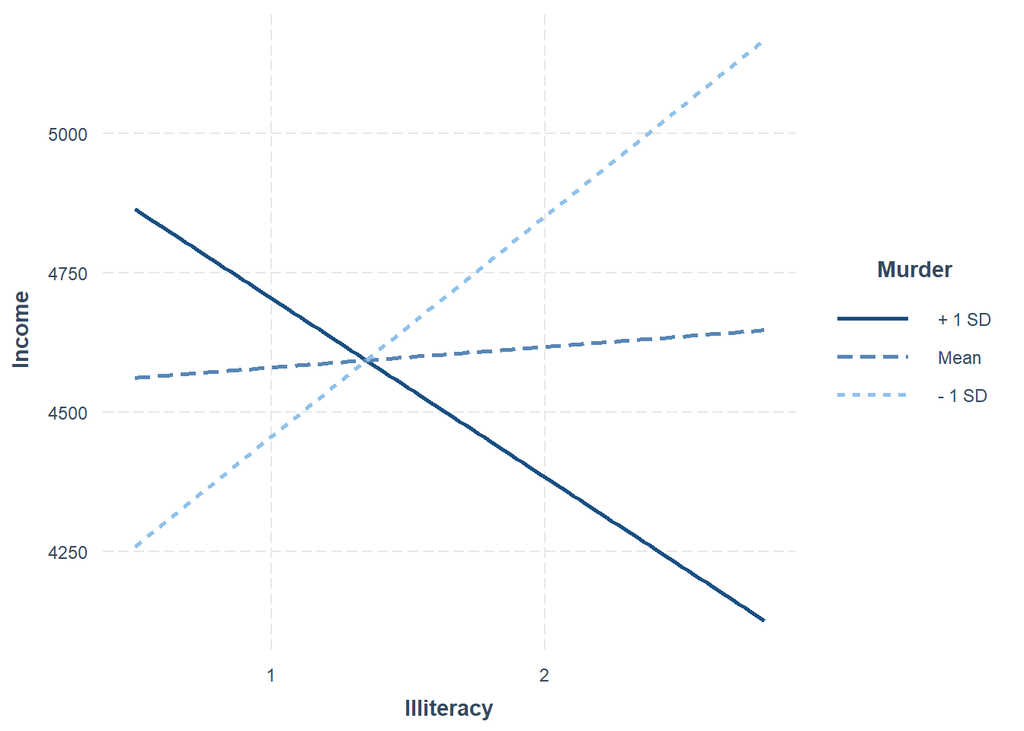

```r
interact_plot(fiti, pred = Illiteracy, modx = Murder)
```

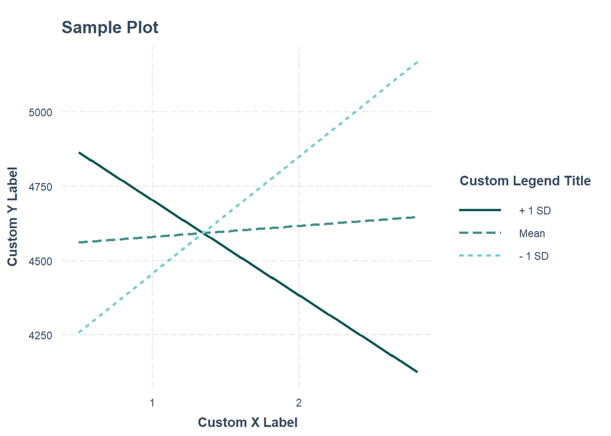

```r
## Other options
interact_plot(fiti, pred = Illiteracy, modx = Murder,
              x.label = "Custom X Label", y.label = "Custom Y Label",
              main.title = "Sample Plot",  legend.main = "Custom Legend Title",
              colors = "seagreen")
```

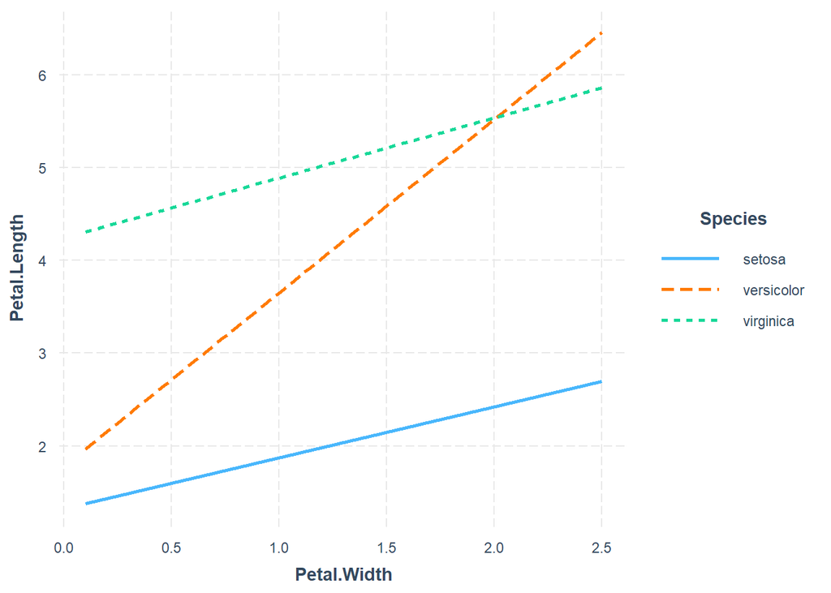

```r
## 因素，则将绘制每个级别
fitiris <- lm(Petal.Length ~ Petal.Width * Species, data = iris)
interact_plot(fitiris, pred = Petal.Width, modx = Species)
```

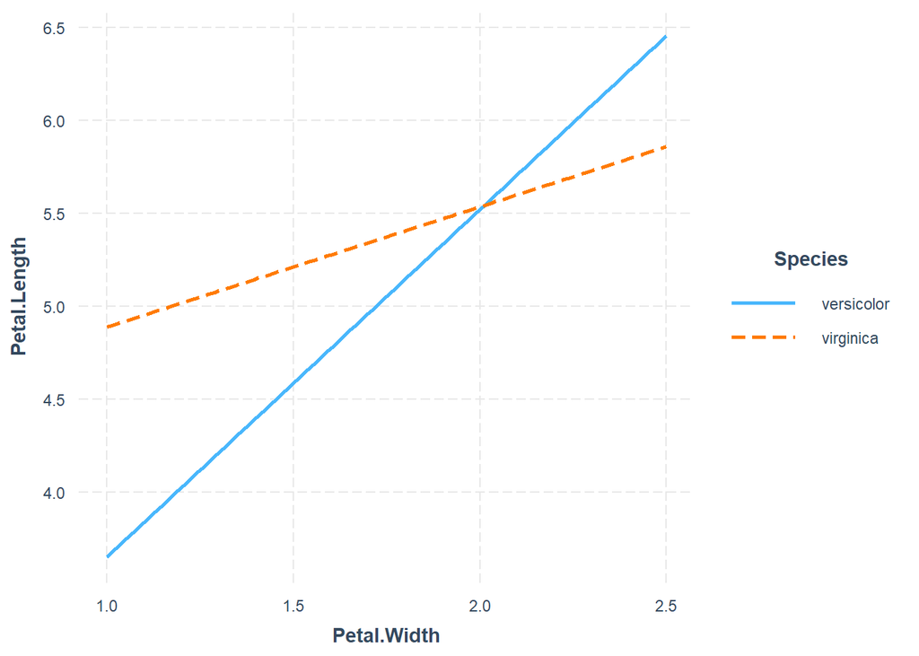

```r
## Specify a subset of a factor’s levels
interact_plot(fitiris, pred = Petal.Width, modx = Species,
              modx.values = c("versicolor", "virginica"))
```

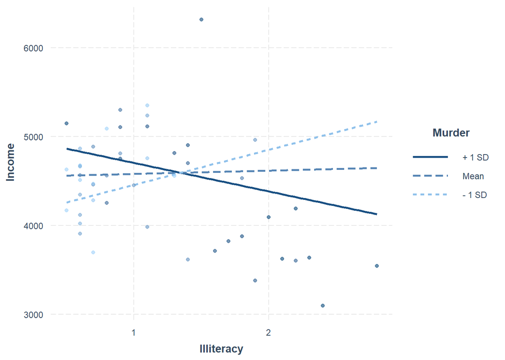

```r
## Plotting observed data
## plot.points = TRUE argument.


## continuous
interact_plot(fiti, pred = Illiteracy, modx = Murder, plot.points = TRUE)
```

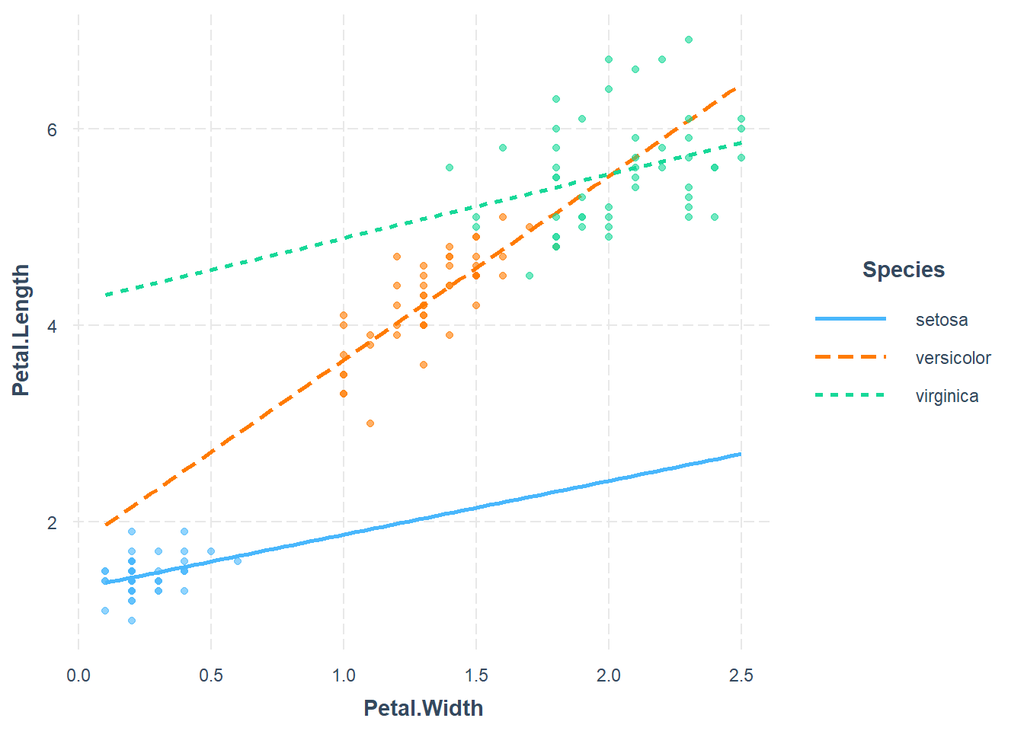

```r
## categorical
interact_plot(fitiris, pred = Petal.Width, modx = Species,
              plot.points = TRUE)
```

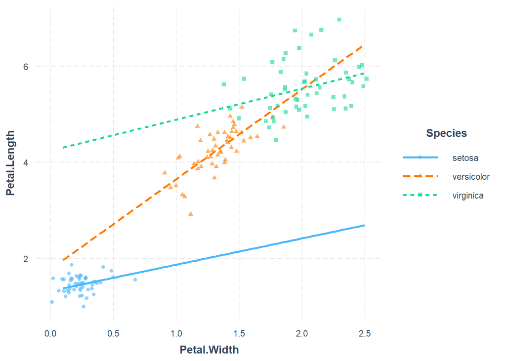

```r
## random “jitter”
   ## 许多点稍微重叠的地方，应用随机的“抖动”将其稍微移动以停止重叠可能会很有用。 使用抖动参数执行此操作。
## point.shape
   ## point.shape = TRUE为每个点赋予不同的形状
interact_plot(fitiris, pred = Petal.Width, modx = Species,
              plot.points = TRUE, jitter = 0.1, point.shape = TRUE)
```

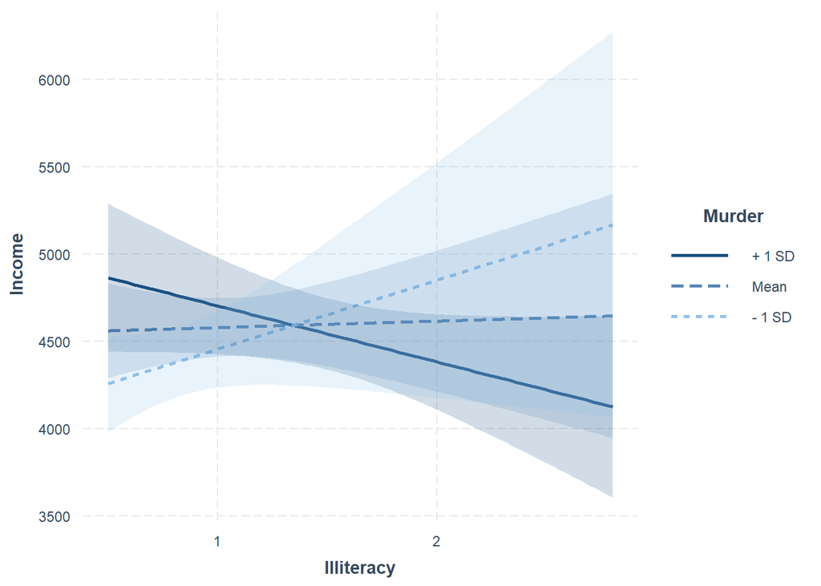

```r
## Confidence bands
   ## robust argument to plot confidence intervals based on robust standard error calculations.
interact_plot(fiti, pred = Illiteracy, modx = Murder, interval = TRUE,
              int.width = 0.8)
```

### Check linearity assumption

The basic assumption of linear regression is that the relationship between the predictor variable and the response variable is linear. When you have an interaction, you can add the assumption that the relationship between the predictor and the response is linear, regardless of the level of the moderator. If the relationship is non-linear, it will bend.

```r
set.seed(99)
x <- rnorm(n = 200, mean = 3, sd = 1)
err <- rnorm(n = 200, mean = 0, sd = 4)
w <- rbinom(n = 200, size = 1, prob = 0.5)

y_1 <- 5 - 4*x - 9*w + 3*w*x + err
model_1 <- lm(y_1 ~ x * w)
summ(model_1)
```

| Observations | 200 |
| --- | --- |
| Dependent variable | y_1 |
| Type | OLS linear regression |

| F(3,196) | 25.93 |
| --- | --- |
| R² | 0.28 |
| Adj. R² | 0.27 |

|  | Est. | S.E. | t val. | p |
| --- | --- | --- | --- | --- |
| (Intercept) | 3.19 | 1.29 | 2.47 | 0.01 |
| x | -3.59 | 0.42 | -8.61 | 0.00 |
| w | -7.77 | 1.90 | -4.10 | 0.00 |
| x:w | 2.86 | 0.62 | 4.62 | 0.00 |

Standard errors: OLS

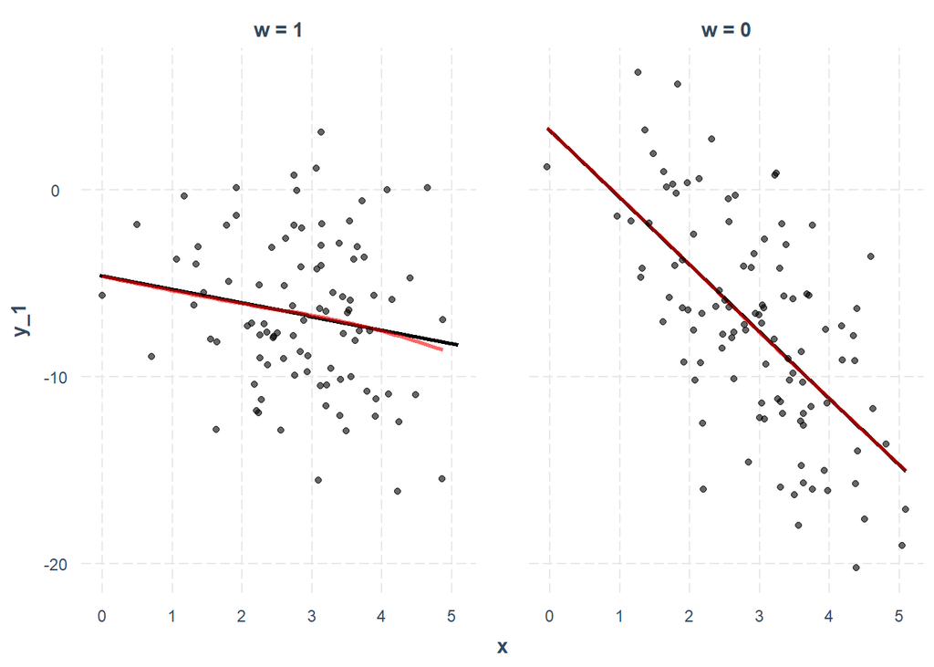

```r
##  the assumption is satisfied.
interact_plot(model_1, pred = x, modx = w, linearity.check = TRUE,
              plot.points = TRUE)
```

```r
x_2 <- runif(n = 200, min = -3, max = 3)
y_2 <- 2.5 - x_2^2 - 5*w + 2*w*(x_2^2) + err
data_2 <- as.data.frame(cbind(x_2, y_2, w))

##  the linearity assumption will be violated
model_2 <- lm(y_2 ~ x_2 * w, data = data_2)
summ(model_2)
```

| Observations | 200 |
| --- | --- |
| Dependent variable | y_2 |
| Type | OLS linear regression |

| F(3,196) | 3.28 |
| --- | --- |
| R² | 0.05 |
| Adj. R² | 0.03 |

|  | Est. | S.E. | t val. | p |
| --- | --- | --- | --- | --- |
| (Intercept) | -0.75 | 0.49 | -1.51 | 0.13 |
| x_2 | 0.53 | 0.30 | 1.77 | 0.08 |
| w | 1.63 | 0.72 | 2.28 | 0.02 |
| x_2:w | -0.25 | 0.42 | -0.61 | 0.54 |

Standard errors: OLS

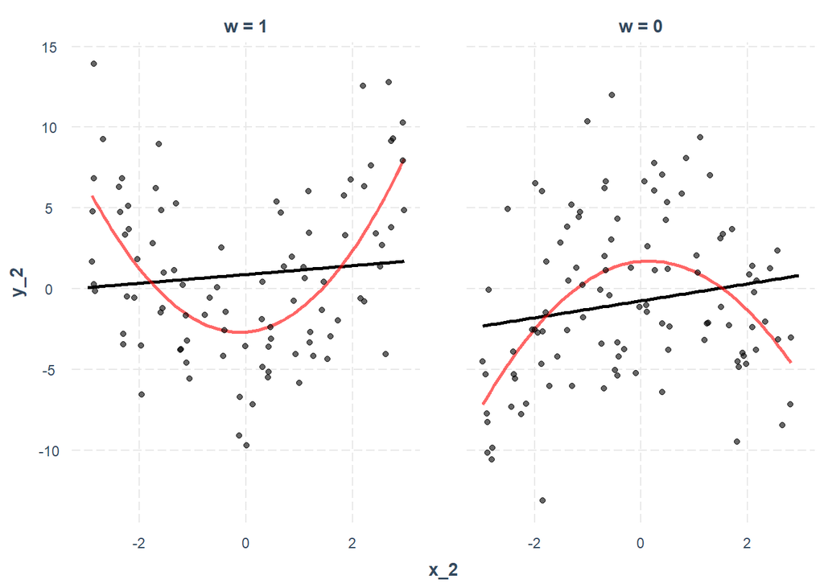

```r
interact_plot(model_2, pred = x_2, modx = w, linearity.check = TRUE,
              plot.points = TRUE)
```

```r
## 使用以下polynomial多项式来拟合此真实模型
model_3 <- lm(y_2 ~ poly(x_2, 2) * w, data = data_2)
summ(model_3)
```

| Observations | 200 |
| --- | --- |
| Dependent variable | y_2 |
| Type | OLS linear regression |

| F(5,194) | 18.32 |
| --- | --- |
| R² | 0.32 |
| Adj. R² | 0.30 |

|  | Est. | S.E. | t val. | p |
| --- | --- | --- | --- | --- |
| (Intercept) | -1.01 | 0.42 | -2.41 | 0.02 |
| poly(x_2, 2)1 | 9.90 | 6.14 | 1.61 | 0.11 |
| poly(x_2, 2)2 | -34.14 | 6.15 | -5.55 | 0.00 |
| w | 1.61 | 0.61 | 2.65 | 0.01 |
| poly(x_2, 2)1:w | -6.33 | 8.60 | -0.74 | 0.46 |
| poly(x_2, 2)2:w | 75.58 | 8.62 | 8.77 | 0.00 |

Standard errors: OLS

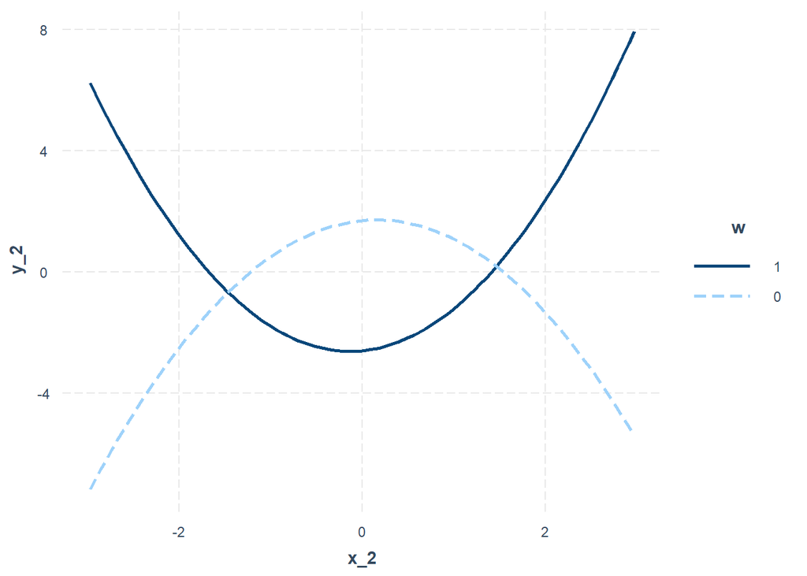

```r
interact_plot(model_3, pred = x_2, modx = w, data = data_2)
```

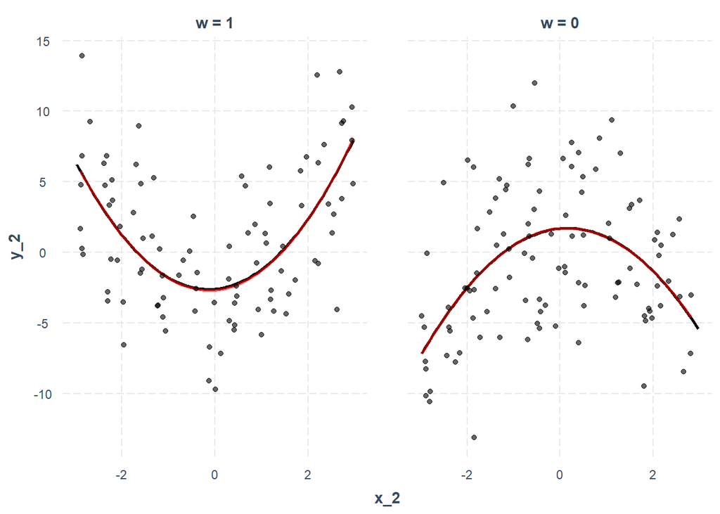

```r
##  non-linearity check:
interact_plot(model_3, pred = x_2, modx = w, data = data_2,
              linearity.check = TRUE, plot.points = TRUE)
```

## Collinearity

When some predictors are linear combinations of others, then $X^{T} X$ is singular, and we have (exact) collinearity. There is no unique least squares estimate of $\beta$ If $X^{T} X$ is close to singular, we have collinearity (some call it multicollinearity). This causes serious problems with the estimation of $\beta$ and associated quantities, as well as the interpretation.

共线性可以通过以下几种方式检测：

1. 检查预测变量的相关矩阵可能会显示较大的成对共线性。
2. 将 $x_{i}$ 对所有其他预测变量进行回归得到 $R_{i}^{2}$ 。 对所有预测变量重复上述步骤。 $R_{i}^{2}$ 接近1表示有问 题。 令人讨厌的线性组合可以通过检查这些回归系数来发现。
3. 检查 $X^{T} X$, 的特征值，其中 $\lambda_{1}$ 是最大特征值，其他特征值递减。特征值较小表示存在问题。

```
data (seatpos)
g < - lm (hipcenter ˜ . , seatpos)
summary (g)
round(cor(seatpos), 3)

## check the eigendecomposition:
x < - model.matrix(g)[,-1]
e < - eigen (t(x) %*% x)
e$val

sqrt(e$val[1]/e$val)
1.000 13.042 20.100 110.551 156.912 212.156 261.667 707.549


## check the variance inflation factors (VIFs).
   For the first variable this is:
summary (lm (x [, 1] ~ x[,-1]))$r.squared
[1] 0.49948
1/(1!0.49948)
[1] 1.9979


## It is generally believed that a VIF value of more than 5 (some people think it is 10)
## indicates that there is serious collinearity
vif (x)
Age Weight HtShoes Ht Seated Arm Thigh  Leg
1.9979 3.6470 307.4294 333.1378 8.9511 4.4964 2.7629 6.6943
```

## Problems with the Error

关于误差项 $\varepsilon$ 的标准假设是，它根据情况是独立且均匀分布的 （independent and identically distributed iid) 。即 $\varepsilon=\sigma^{2} I$ 。 此外，我们还假定误差是正态分布的，以便执行 通常的统计推断。我们已经看到, 这些假设经常会被违反，因此我们必须考虑其他选择。

- 当误差不是i.i.d.时，我们考虑使用广义最小二乘（GLS）。
- 当误差是独立的，但分布不相同时，我们可以使用加权最小二乘（WLS），这是GLS的特例。
- 当误差不是正态分布时，我们可以使用鲁棒回归

### Generalized Least Squares

到现在为止，我们假设var $\varepsilon=\sigma^{2} I,$, 但有时错误具有非恒定方差或相关。假设var $\varepsilon=\sigma^{2} \Sigma$, 其中 $\sigma^{2}$ 是未知的，而 $\Sigma$ 是已知的-换句话说，我们知道误差之间的相关性和相对方差，但我们不知道绝对比 例。 我们可以写 $\Sigma=S S^{T},$, 其中 $S$ 是使用Choleski分解的三角矩阵（triangular matrix) 。现在我们可以按 如下方式转换回归模型：
$$\begin{array}{c}
y=X \beta+\varepsilon \\
S^{-1} y=S^{-1} X \beta+S^{-1} \varepsilon \\
y^{\prime}=X^{\prime} \beta+\varepsilon^{\prime} \\
\operatorname{var} \varepsilon^{\prime}=\operatorname{var}\left(S^{-1} \varepsilon\right)=S^{-1}(\operatorname{var} \varepsilon) S^{-T}=S^{-1} \sigma^{2} S S^{T} S^{-T}=\sigma^{2} I
\end{array}$$
因此，我们可以将GLS 简化为OLS, 通过 $y^{\prime}=S^{-1} y$ on $S^{-1} X$,误差为 $\varepsilon^{\prime}$ 即iid. 我们只是将问题简化为 我们已经解决的问题。在此转换后的模型中，平方和为：
$$\left(S^{-1} y-S^{-1} X \beta\right)^{T}\left(S^{-1} y-S^{-1} X \beta\right)=(y-X \beta)^{T} S^{-T} S^{-1}(y-X \beta)=(y-X \beta)^{T} \Sigma^{-1}(y-X \beta)$$
which is minimized by:
$$\hat{\boldsymbol{\beta}}=\left(X^{T} \Sigma^{-1} X\right)^{-1} X^{T} \Sigma^{-1} y$$
We find that:
$$\operatorname{var} \hat{\boldsymbol{\beta}}=\left(X^{T} \Sigma^{-1} X\right)^{-1} \sigma^{2}$$
Since $\varepsilon^{\prime}=S^{-1} \varepsilon$, diagnostics should be applied to the residuals, $S^{-1} \hat{\varepsilon} .$ If we have the right $\Sigma$, then these should be approximately i.i.d. 在Pinheiro和Bates（2000）的nlme软件包中找到更方便的方法，该软件包包含GLS拟合函数。我们可以 使用它来拟合此模型：

```r
library (nlme)
fm1 <- gls(follicles ~ sin(2*pi*Time) + cos(2*pi*Time), Ovary,
           correlation = corAR1(form = ~ 1 | Mare))
summary(fm1)
```

```
## Generalized least squares fit by REML
##   Model: follicles ~ sin(2 * pi * Time) + cos(2 * pi * Time)
##   Data: Ovary
##        AIC      BIC    logLik
##   1571.455 1590.056 -780.7273
##
## Correlation Structure: AR(1)
##  Formula: ~1 | Mare
##  Parameter estimate(s):
##       Phi
## 0.7532079
##
## Coefficients:
##                        Value Std.Error   t-value p-value
## (Intercept)        12.216398 0.6646437 18.380373  0.0000
## sin(2 * pi * Time) -2.774712 0.6450478 -4.301561  0.0000
## cos(2 * pi * Time) -0.899605 0.6975383 -1.289685  0.1981
##
##  Correlation:
##                    (Intr) s(*p*T
## sin(2 * pi * Time)  0.000
## cos(2 * pi * Time) -0.294  0.000
##
## Standardized residuals:
##         Min          Q1         Med          Q3         Max
## -2.41180365 -0.75405234 -0.02923628  0.63156880  3.16247697
##
## Residual standard error: 4.616172
## Degrees of freedom: 308 total; 305 residual
```

```r
## check the confidence intervals
intervals (fm1)
```

```
## Approximate 95% confidence intervals
##
##  Coefficients:
##                        lower       est.      upper
## (Intercept)        10.908531 12.2163982 13.5242656
## sin(2 * pi * Time) -4.044019 -2.7747122 -1.5054050
## cos(2 * pi * Time) -2.272201 -0.8996047  0.4729919
## attr(,"label")
## [1] "Coefficients:"
##
##  Correlation structure:
##         lower      est.     upper
## Phi 0.6684283 0.7532079 0.8186662
## attr(,"label")
## [1] "Correlation structure:"
##
##  Residual standard error:
##    lower     est.    upper
## 3.974706 4.616172 5.361161
```

### Weighted Least Squares

有时误差是不相关的，但方差不相等。当 $\Sigma$ 是对角矩阵时，误差是不相关的，但不一定具有相等的方 差。在这种情况下可以使用WLS。
$$\Sigma=\operatorname{diag}(1 / \mathrm{w} 1, \ldots, 1 / \mathrm{w} n)$$
其中 $w_{i}$ 是权重, $S=\operatorname{diag}(\sqrt{1 / w 1}, \ldots, \sqrt{1 / w n})$ 因此我们可以将 $\sqrt{w_{i}} y_{i}$ 上的 $\sqrt{w_{i}} x_{i}$ 回归（尽 管需要替换 $X$ -matrix中的一列 与 )。变异性低的案例应获得较高的权重，变异性高的案例应获 得较低的权重。 Das Modell
$$\boldsymbol{y}=\boldsymbol{X} \boldsymbol{\beta}+\boldsymbol{\varepsilon}$$

**weights options**

an optional vector of weights to be used in the fitting process. Should be NULL or a numeric vector. If non-NULL, weighted least squares is used with weights weights (that is, minimizing sum(w*e^2)); otherwise ordinary least squares is used.

### Robust Regression

When the error is normal, the least squares regression is obviously the best, but when the error is non-normal, other methods can be considered. Of particular interest are long-tailed error distributions. Robust regression provides an alternative. Robust regression is related to WLS.

1. 健壮的估计器可防止长尾误差，但无法克服模型选择及其方差结构方面的问题。
2. 健壮的估算仅能为您提供 $\hat{\beta}$ 以及可能的标准错误，而没有相关的推论方法。
3. 除最小二乘法外，还可以使用鲁棒的方法作为确认方法。如果这两个估计值相距甚远，则有理由担 心。差异的来源应进行调查。

## Shrinkage Methods

### Principal Components Analzsis

### Partial Least Squares

Partial Least Squares (PLS) is a method used to associate a set of input variables X1,…Xm with outputs Y1,…,Y1. PLS regression is comparable to PCR because both use a certain number of linear combinations of predictors to predict the response. The difference is that although PCR ignores Y when determining linear combinations, PLS regression explicitly selects them to predict Y as much as possible. We will only consider univariate PLS

$$\hat{y}=\beta_{1} T_{1}+\cdots+\beta_{p} T_{p}$$

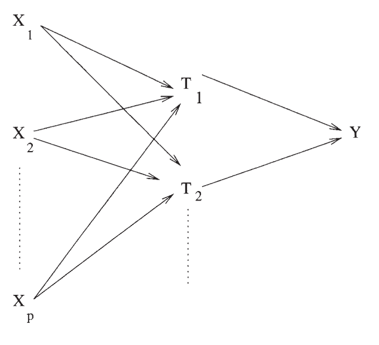

Figure: Partial Least Squares

### Ridge Regression

$$\hat{\boldsymbol{\beta}}=\left(X^{T} X+\lambda I\right)^{-1} X^{T} y$$
We demonstrate the method on the meat spectroscopy data; $\lambda=0$ corresponds to least squares while we find that as $\lambda \rightarrow \infty: \hat{\beta} \rightarrow 0$

The Ridge regression estimates of coefficients are biased. Deviation is undesirable, but it is not the only consideration. The mean square error (MSE) can be decomposed in the following ways:

$$E(\hat{\beta}-\beta)^{2}=(E(\hat{\beta}-\beta))^{2}+E(\hat{\beta}-E \hat{\beta})^{2}$$

因此，估计的MSE可以表示为偏差的平方加方差。 有时，可以以增加偏差为代价获得方差的大幅减少。 如果结果导致MSE降低，那么我们可能愿意接受一些偏见。 这就是岭回归所要做出的权衡—以偏差增加为代价减少方差。 这是一个常见的难题。 Frank and Friedman（1993）比较了PCR，PLS和岭回归，发现岭回归的最佳结果。 当然，对于任何给定的数据集，任何一种方法都可能被证明是最好的，因此很难选择一个获胜者